This is the accompanying web page for Chapter 3 in my thesis. It provides audio examples for Section 3.5.1 "Experimental Validation of audioLIME: Detecting a Confounder" and Section 3.6 "Demonstration on Real-world Data: Automated Music Tagging".

Note: In Firefox some of the audio controls display incorrect durations (this is a known bug). But the audios are played correctly.

```python
from demo_utils import display_audio, display_markdown
from demo_utils import SAMPLE_RATE, MUSICNN_SAMPLE_LENGTH
from demo_utils import get_top_explaining_component

from IPython.display import Image
```

# Experimental Validation of audioLIME: Detecting a Confounder (Section 3.5.1)

## Dataset Creation & "Confused" Classifier

Here we show a few examples (10 second snippets) from the dataset for the "Guitar vs. Piano" task. In the training, validation and standard test set each "Guitar" example contains guitar, bass, and drums, and each "Piano" example contains piano and bass. In the confused test set each "Guitar" example contains guitar and bass, and each "Piano" example contains piano, bass, and drums.

Next to the track name you see the predictions by the model GP$_{\text{bass}}$ (averaged over the 5 2-second windows without overlap).

|  | Guitar (=0) | Piano (=1) |
| --- | --- | --- |
| train | Track00005 ($\hat{y}=0.0$) | Track00008 ($\hat{y}=0.996$) |
| validation | Track01501 ($\hat{y}=0.0$) | Track01504 ($\hat{y}=0.999$) |
| test_std | Track02098 ($\hat{y}=0.0$) | Track02095 ($\hat{y}=0.991$) |
| test_confused | Track02098 ($\hat{y}=0.251$) | Track02095 ($\hat{y}=0.0$) |

## Detecting the Confounding Class

When we listen to the bottom right sample (test_confused / Track02095) we wonder why the model didn't recognize it as piano, and why it can be so sure that it is a guitar. We take the first 61 frames (2 seconds) since the model was trained on 2 seconds snippets.

```python
from demo_utils import create_demo_spec, predict_instrument_fn, construct_spec
from demo_utils import cerberus_models_dir

from audioLIME.factorization import CerberusFactorization
```

```python
audio_path = 'audio/02095_pianodrums_b_snippet.wav'
S_gp = create_demo_spec(audio_path)
```

Each factorization object for different models (Cerberus, OVA, Spleeter, ...) provides the same functionality. Differences are taken care of in the constructor, so we need to pass everything that the corresponding model needs for estimating the sources. For this example we are using a Cerberus model that estimates {piano, guitar, bass, drums}.

```python
cerberus_model_name = 'Cerberus - pno/gtr/bss/drm'
cerberus_factorization = CerberusFactorization(cerberus_models_dir, cerberus_model_name, audio_path,
                                               construct_spec,
                                               start_sample=0, y_length=MUSICNN_SAMPLE_LENGTH)

target_idx = 0 # we want an explanation for guitar
```

```python
top_component_gp = get_top_explaining_component(x=S_gp, predict_fn=predict_instrument_fn, labels=[target_idx], factorization=cerberus_factorization)
```

#### Now we are listening to the explanation for "guitar"

```python
display_audio(top_component_gp)
```

[interactive chart not shown]

Sounds like our model learned to confound drums with guitar!

# Demonstration on Real-World Data: Automated Music Tagging (Section 3.6)

In this section we demonstrate audioLIME on a two real recordings from [MUSDB18](https://sigsep.github.io/datasets/musdb.html) and a song found on YouTube.

```python
from audioLIME.factorization import FakeMusDBFactorization, SpleeterFactorization
from demo_utils import prepare_musdb_demo_example, predict_fn_MSD_musicnn_big
```

## Qualitative comparison of musicnn_MSD_big tags and MUSDB18 genres

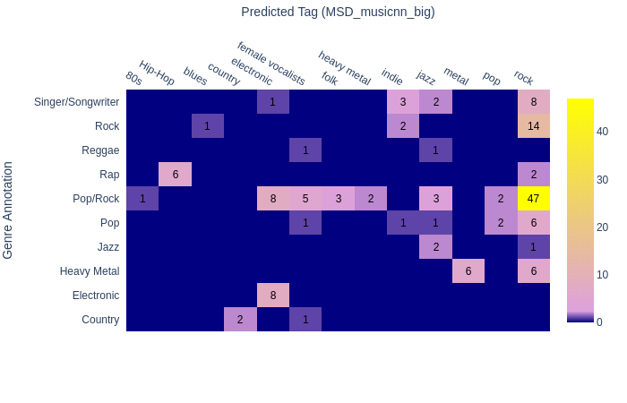

```python
Image("musicnn_musdb.png")
```

We can see some obviously "correct" predictions, e.g. tagging 47 Rock/Pop songs as rock, tagging 6 Rap songs as Hip-Hop, tagging 2 Country songs as country and so on and so forth. For some genres (Singer/Songwriter) and tags (80s, female vocalists), it is not as obvious, but the predictions can be checked by looking up the songs, e.g. the prediction '80s' for the song 'Speak Softly - Broken Man' is incorrect, the song is from 2012. Overall MSD_musicnn_big performs reasonably well on this dataset.

## MSD_musicnn_big on MUSDB18 with oracle separation & spleeter:5stems

Here we demonstrate the usage of audioLIME on two examples using (a) oracle separation and (b) separation with the model spleeter:5stems.

### Actions - Devil's Words

The top tag for this song is 'female vocalists'. For the demonstration we pick a snippet (since musicnn operates on 3 second snippets) whose prediction is also 'female vocalists' (starting at 25 seconds) and ask audioLIME for an explanation.

```python
target_idx_female = 5
sample_start = 25*SAMPLE_RATE
y_snip_devils_words, mus_devils_words = prepare_musdb_demo_example(selected_idx=4, sample_start=sample_start)
```

Input Audio

[interactive chart not shown]

```
Top tags: ['female vocalists', 'pop', 'electronic']
```

```python
musdb_factorization = FakeMusDBFactorization(mus_devils_words, sample_start, MUSICNN_SAMPLE_LENGTH, SAMPLE_RATE)
spleeter_factorization = SpleeterFactorization('spleeter:5stems', mus_devils_words.path, None, sample_start, MUSICNN_SAMPLE_LENGTH)
```

#### What does the explanation for 'female vocalists' sound like?

#### Oracle Separation

```python
top_component_md_devils = get_top_explaining_component(x=y_snip_devils_words,
                                                       predict_fn=predict_fn_MSD_musicnn_big,
                                                       labels=[target_idx_female],
                                                       factorization=musdb_factorization, batch_size=1) # musicnn only takes 1 sample at a time
display_audio(top_component_md_devils, sr=SAMPLE_RATE)
```

[interactive chart not shown]

#### Separation using spleeter:5stems

```python
top_component_spl_devils = get_top_explaining_component(x=y_snip_devils_words,
                                                        predict_fn=predict_fn_MSD_musicnn_big,
                                                        labels=[target_idx_female],
                                                        factorization=spleeter_factorization,
                                                        batch_size=1) # musicnn only takes 1 sample at a time


display_audio(top_component_spl_devils, sr=SAMPLE_RATE)
```

[interactive chart not shown]

With both separation approaches we can hear that the singing voice in the song is responsible for the prediction "female vocalist", which is great! This increases our trust that the model learned something about this tag.

### ANiMAL - Easy Tiger

```python
target_idx_hiphop = 33
sample_start = 47 * MUSICNN_SAMPLE_LENGTH # the 47th snippet has the highest prediction for Hip-Hop (0.817)
y_snip_easy_tiger, mus_easy_tiger = prepare_musdb_demo_example(selected_idx=2, sample_start=sample_start)
```

Input Audio

[interactive chart not shown]

```
Top tags: ['Hip-Hop', 'rock', 'jazz']
```

```python
musdb_factorization = FakeMusDBFactorization(mus_easy_tiger, sample_start, MUSICNN_SAMPLE_LENGTH, SAMPLE_RATE)
spleeter_factorization = SpleeterFactorization('spleeter:5stems', mus_easy_tiger.path, None, sample_start, MUSICNN_SAMPLE_LENGTH)
```

#### What does the explanation for 'Hip-Hop' sound like?

#### Oracle Separation

```python
top_component_md_tiger = get_top_explaining_component(x=y_snip_easy_tiger,
                                                       predict_fn=predict_fn_MSD_musicnn_big,
                                                       labels=[target_idx_hiphop],
                                                       factorization=musdb_factorization, batch_size=1)

display_audio(top_component_md_tiger, sr=SAMPLE_RATE)
```

[interactive chart not shown]

#### Separation using spleeter:5stems

```python
top_component_spl_tiger = get_top_explaining_component(x=y_snip_easy_tiger,
                                                        predict_fn=predict_fn_MSD_musicnn_big,
                                                        labels=[target_idx_hiphop],
                                                        factorization=spleeter_factorization,
                                                        batch_size=1) # musicnn only takes 1 sample at a time

display_audio(top_component_spl_tiger, sr=SAMPLE_RATE)
```

[interactive chart not shown]

Again, the singing voice in the song was responsible for making the prediction "Hip-Hop". This does not mean, however, that singing voice in general will increase the probability of the tag "Hip-Hop". It tells s that it is something related to vocal qualities that indicate this tag. As we may expect that characteristics of the vocals are strongly related to this genre, this increases our confidence that this model has actually learned something about Hip-Hop.

## Hugh Laurie - Saint James Infirmary (Let Them Talk, A Celebration of New Orleans Blues)

In this section we test audioLIME using spleeter:5stems as our separation model on a song found on YouTube. Unfortunately the video owner disabled playback on other websites, please click "Watch on YouTube."

The predictions and analyses are performed on 3-second snippets (because this is how the model is implemented), and each snippet is treated individually. This is different from temporal segmentation mentioned in the paper (see Section 2.2), which would segment each 3-second input snippet in the desired number of segments.

```python
import IPython.display as ipd
ipd.YouTubeVideo('AzEBH6DZJVk', width=600, height=450)
```

[video not shown]

We only show a subset of the 50 tags. We pick the ones that have at least one snippet > 0.3.

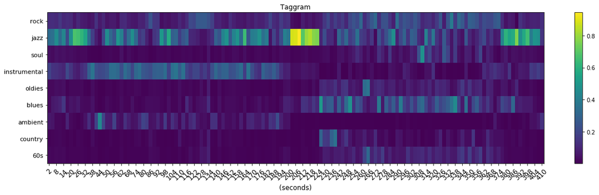

```python
Image('img/taggram_hugh_laurie.png')
```

We pick 3 snippets from different parts of the song that have a high prediction for jazz (starting at 21, 206 and 386 seconds). In the first snippet (starting at 21 seconds) we can only hear the piano and some noise. In the second snippet (starting at 206) we can hear several instruments and in the third snippet (starting at 386 seconds) addtional to instruments we also hear singing voice.

| Start (sec.) | Snippet | $p(\hat{y}=\text{'jazz'})$ | Explanation |
| --- | --- | --- | --- |
| 21 |  | 0.63 |  |
| 206 |  | 0.95 |  |
| 386 |  | 0.76 |  |

The prediction for the first snippet is explained by the "piano", and not the noisy part of the audio. The second snippet is also explained by "piano" and not by the other instruments. The third snippet, although it contains distinctive singing voice, is also explained by the "piano" in it.

Now we have 3 very different snippets, in which the probability for "jazz" is very high and in each case the explanation is the "piano" part of the snippets. We believe that the model learned to relate the piano to the tag "jazz". This does not necessarily mean that the presence of piano leads to a high probability of "jazz" per se, but that the model learned to relate specific characteristics of how the piano sounds in those songs to the tag "jazz".